# DTs classification

[figure not shown]

## [Prof. Pedram Jahangiry](https://huntsman.usu.edu/directory/jahangiry-pedram)

[GitHub account](https://github.com/PJalgotrader)

[YouTube Channel](https://www.youtube.com/channel/UCNDElcuuyX-2pSatVBDpJJQ/playlists)

# Decision Trees Classification

Importing the packages:

```python
import numpy as np
import pandas as pd
import matplotlib.pyplot as plt
import seaborn as sns
sns.set()  #if you want to use seaborn themes with matplotlib functions
import warnings
warnings.filterwarnings('ignore')
```

```python
rand_state = 1000
```

```python
df = pd.read_csv('Social_Network_Ads.csv')
```

```python
df.head()
```

|  | User ID | Gender | Age | EstimatedSalary | Purchased |
| --- | --- | --- | --- | --- | --- |
| 0 | 15624510 | Male | 19 | 19000 | 0 |
| 1 | 15810944 | Male | 35 | 20000 | 0 |
| 2 | 15668575 | Female | 26 | 43000 | 0 |
| 3 | 15603246 | Female | 27 | 57000 | 0 |
| 4 | 15804002 | Male | 19 | 76000 | 0 |

```python
df.info()
```

```
<class 'pandas.core.frame.DataFrame'>
RangeIndex: 400 entries, 0 to 399
Data columns (total 5 columns):
User ID            400 non-null int64
Gender             400 non-null object
Age                400 non-null int64
EstimatedSalary    400 non-null int64
Purchased          400 non-null int64
dtypes: int64(4), object(1)
memory usage: 15.7+ KB
```

```python
# first we look at target variable proportions:
pd.crosstab(df['Purchased'],df['Purchased'], normalize='all')*100
```

| Purchased | 0 | 1 |
| --- | --- | --- |
| 0 | 64.25 | 0.00 |
| 1 | 0.00 | 35.75 |

## Data preprocessing

```python
df.isna().sum()
```

```
User ID            0
Gender             0
Age                0
EstimatedSalary    0
Purchased          0
dtype: int64
```

```python
df.drop('User ID',axis=1, inplace=True)
```

### Dealing with categorical variables:

In DTs models, we don't need to transfer the categorical variables into dummy variables. However, the algorithm cannot handle string names either. So we should number code the categorical variables.

```python
df['Gender'] = np.where(df['Gender']=='Male',1,0)
```

```python
df.columns
```

```
Index(['Gender', 'Age', 'EstimatedSalary', 'Purchased'], dtype='object')
```

```python
df = df[['Purchased','Age', 'EstimatedSalary', 'Gender']]
```

```python
df.head()
```

|  | Purchased | Age | EstimatedSalary | Gender |
| --- | --- | --- | --- | --- |
| 0 | 0 | 19 | 19000 | 1 |
| 1 | 0 | 35 | 20000 | 1 |
| 2 | 0 | 26 | 43000 | 0 |
| 3 | 0 | 27 | 57000 | 0 |
| 4 | 0 | 19 | 76000 | 1 |

## Data visualization

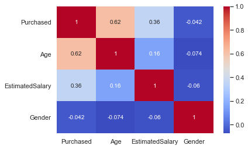

```python
sns.heatmap(df.corr(), cmap='coolwarm',annot=True)
plt.show()
```

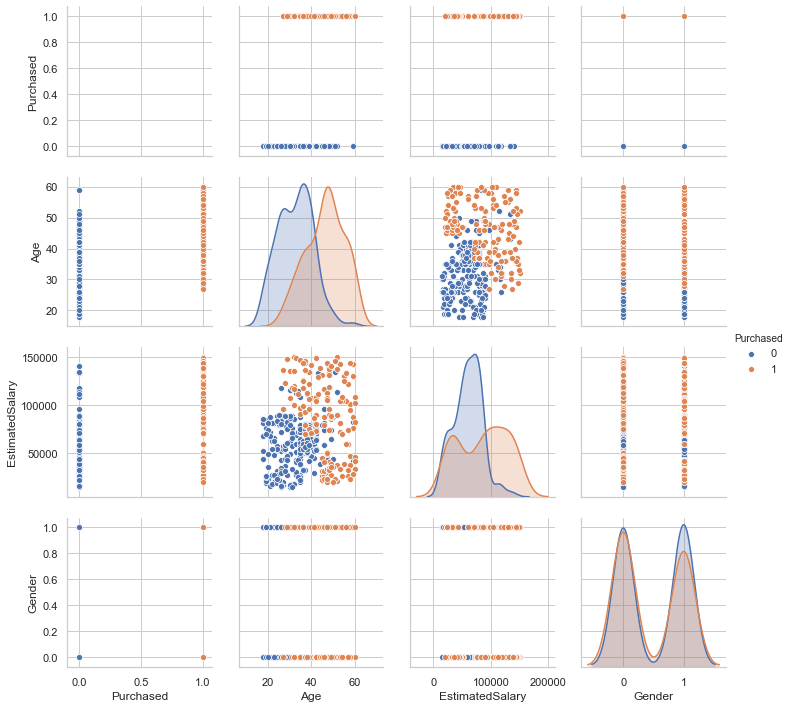

```python
sns.set_style('whitegrid')
sns.pairplot(df, hue= 'Purchased')
plt.show()
```

### Defining the variables and splitting the data

```python
y = df['Purchased']
X = df.drop('Purchased', axis=1) # becareful inplace= False

from sklearn.model_selection import train_test_split
X_train, X_test, y_train, y_test = train_test_split(X, y, test_size=0.2, random_state=rand_state)
```

```python
X_train.head()
```

|  | Age | EstimatedSalary | Gender |
| --- | --- | --- | --- |
| 269 | 40 | 61000 | 1 |
| 389 | 48 | 35000 | 0 |
| 232 | 40 | 107000 | 1 |
| 89 | 35 | 50000 | 1 |
| 236 | 40 | 57000 | 1 |

### Scaling the features:

For tree based models, there is no need to scale the features! (No distance metrics is used)

### DTs Classification with Sklearn

```python
from sklearn.tree import DecisionTreeClassifier
```

```python
Tree_classifier = DecisionTreeClassifier()
Tree_classifier.fit(X_train, y_train)
```

```
DecisionTreeClassifier()
```

```python
# Predicting the Test set classes
y_hat       = Tree_classifier.predict(X_test)
```

## Performance metrics:

```python
from sklearn.metrics import accuracy_score, recall_score, precision_score, f1_score
from sklearn.metrics import confusion_matrix, classification_report, roc_curve, roc_auc_score
```

#### Confusion matrix

```python
print(confusion_matrix(y_test, y_hat))
```

```
[[44  4]
 [14 18]]
```

#### Built-in classification report

```python
print(classification_report(y_test, y_hat))
```

```
              precision    recall  f1-score   support

           0       0.76      0.92      0.83        48
           1       0.82      0.56      0.67        32

    accuracy                           0.78        80
   macro avg       0.79      0.74      0.75        80
weighted avg       0.78      0.78      0.76        80
```

## Pruning the tree using cost complexity pruning method.

### Choosing $\alpha$ with cross validation.

```python
path = DecisionTreeClassifier().cost_complexity_pruning_path(X_train,y_train)
```

```python
path
```

```
{'ccp_alphas': array([0.        , 0.0015625 , 0.0020202 , 0.00203488, 0.00243056,
        0.0025    , 0.0025    , 0.00265625, 0.00273437, 0.00277778,
        0.00284091, 0.003125  , 0.00318723, 0.00357143, 0.00381731,
        0.00511297, 0.00775811, 0.008125  , 0.12078047, 0.18094607]),
 'impurities': array([0.003125  , 0.0046875 , 0.01074811, 0.01685276, 0.02657498,
        0.03157498, 0.03907498, 0.04438748, 0.04985623, 0.05541179,
        0.0610936 , 0.0673436 , 0.08327975, 0.09399404, 0.10162865,
        0.11185459, 0.13512893, 0.15137893, 0.27215939, 0.45310547])}
```

```python
ccp_alphas = path.ccp_alphas
```

```python
from sklearn.model_selection import cross_val_score
import sklearn.metrics
sorted(sklearn.metrics.SCORERS.keys())
```

```
['accuracy',
 'adjusted_mutual_info_score',
 'adjusted_rand_score',
 'average_precision',
 'balanced_accuracy',
 'completeness_score',
 'explained_variance',
 'f1',
 'f1_macro',
 'f1_micro',
 'f1_samples',
 'f1_weighted',
 'fowlkes_mallows_score',
 'homogeneity_score',
 'jaccard',
 'jaccard_macro',
 'jaccard_micro',
 'jaccard_samples',
 'jaccard_weighted',
 'max_error',
 'mutual_info_score',
 'neg_brier_score',
 'neg_log_loss',
 'neg_mean_absolute_error',
 'neg_mean_absolute_percentage_error',
 'neg_mean_gamma_deviance',
 'neg_mean_poisson_deviance',
 'neg_mean_squared_error',
 'neg_mean_squared_log_error',
 'neg_median_absolute_error',
 'neg_root_mean_squared_error',
 'normalized_mutual_info_score',
 'precision',
 'precision_macro',
 'precision_micro',
 'precision_samples',
 'precision_weighted',
 'r2',
 'rand_score',
 'recall',
 'recall_macro',
 'recall_micro',
 'recall_samples',
 'recall_weighted',
 'roc_auc',
 'roc_auc_ovo',
 'roc_auc_ovo_weighted',
 'roc_auc_ovr',
 'roc_auc_ovr_weighted',
 'top_k_accuracy',
 'v_measure_score']
```

```python
accuracy_cv =[]
for alpha in ccp_alphas:
    accuracy = cross_val_score(estimator = DecisionTreeClassifier(ccp_alpha=alpha), X = X_train, y = y_train, cv = 5 , scoring="accuracy" )
    accuracy_cv.append(np.mean(accuracy))

output = pd.DataFrame(list(ccp_alphas), columns=['alpha'])
output['accuracy_CV']=accuracy_cv

output.head()
```

|  | alpha | accuracy_CV |
| --- | --- | --- |
| 0 | 0.000000 | 0.868750 |
| 1 | 0.001562 | 0.875000 |
| 2 | 0.002020 | 0.878125 |
| 3 | 0.002035 | 0.865625 |
| 4 | 0.002431 | 0.865625 |

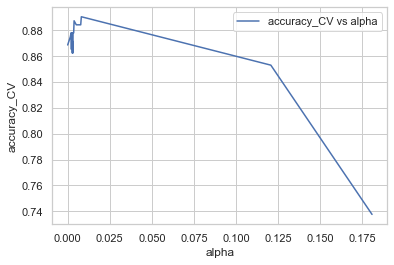

```python
sns.lineplot(x='alpha', y='accuracy_CV', data=output , color='b', label="accuracy_CV vs alpha")
plt.show()
```

```python
np.argmax(output['accuracy_CV'])
```

```
17
```

```python
output.iloc[np.argmax(output['accuracy_CV']),]
```

```
alpha          0.008125
accuracy_CV    0.890625
Name: 17, dtype: float64
```

So the maximum accuracy is 89%.

```python
optimal_alpha = output.iloc[np.argmax(output['accuracy_CV']),0]
optimal_alpha
```

```
0.008125
```

Refit the DTs classifier with optimal alpha!

```python
optimal_DT = DecisionTreeClassifier(ccp_alpha=optimal_alpha)
optimal_DT.fit(X_train, y_train)
y_hat_opt = optimal_DT.predict(X_test)
```

#### Confusion matrix

```python
print(confusion_matrix(y_test, y_hat_opt))
```

```
[[44  4]
 [ 2 30]]
```

#### Built-in classification report

```python
print(classification_report(y_test, y_hat_opt))
```

```
              precision    recall  f1-score   support

           0       0.96      0.92      0.94        48
           1       0.88      0.94      0.91        32

    accuracy                           0.93        80
   macro avg       0.92      0.93      0.92        80
weighted avg       0.93      0.93      0.93        80
```

### Cross validation

Now let's try to get an estimate for the accuracy of our model using cross validation technique.

```python
from sklearn.model_selection import cross_val_score
```

```python
# remember we saved our model in an object called "Tree_classifier"
accuracy = cross_val_score(estimator = optimal_DT, X = X_train, y = y_train, cv = 5 , scoring="accuracy" )
```

```python
accuracy
```

```
array([0.90625 , 0.90625 , 0.859375, 0.921875, 0.859375])
```

```python
round(accuracy.mean(),3)
```

```
0.891
```

## Visualizing the Tree

4 different ways of visualizing a tree in Python: https://mljar.com/blog/visualize-decision-tree/

Plot DT with **plot_tree** method from sklearn.

Let's visualize one simple tree with two features only.

```python
df.columns
```

```
Index(['Purchased', 'Age', 'EstimatedSalary', 'Gender'], dtype='object')
```

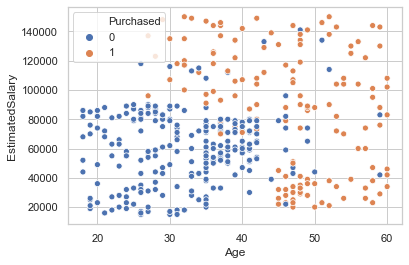

```python
sns.scatterplot(x='Age', y='EstimatedSalary', data=df, hue='Purchased')
plt.show()
```

```python
dtree= DecisionTreeClassifier(max_depth=2, ccp_alpha=0)
dtree.fit(X_train, y_train)
yhat = dtree.predict(X_test)
```

```python
from sklearn import tree
```

```python
X_train.shape
```

```
(320, 3)
```

```python
X_train.head()
```

|  | Age | EstimatedSalary | Gender |
| --- | --- | --- | --- |
| 269 | 40 | 61000 | 1 |
| 389 | 48 | 35000 | 0 |
| 232 | 40 | 107000 | 1 |
| 89 | 35 | 50000 | 1 |
| 236 | 40 | 57000 | 1 |

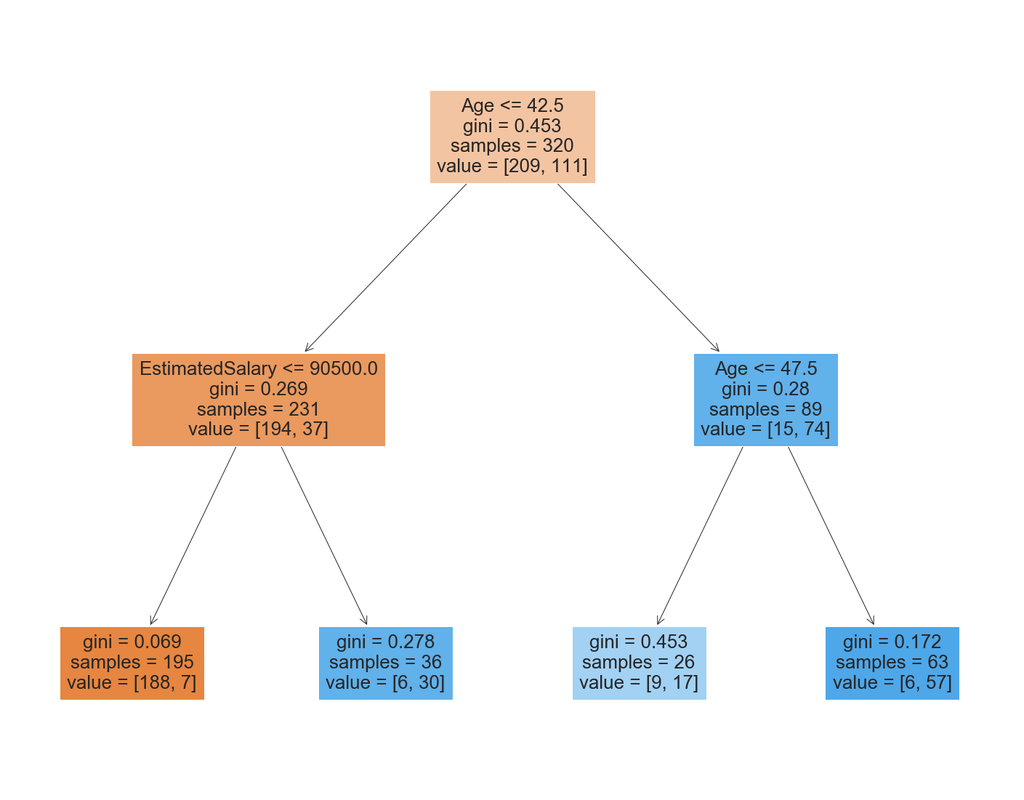

```python
fig = plt.figure(figsize=(25,20))
DT_plot = tree.plot_tree(dtree, feature_names=X_train.columns, filled=True)
# left branch True
```

```python
fig.savefig("DT_plot_classification.png")
```

**Exercise**: Now try the optimal alpha and answer the following questions:

1. What is the level?
2. What is |T|?
3. How do you make sure that each terminal node has at least 50 boservations?

### Advance Visualization (this part is optional)

Visualising the Training set results (in 2D of course!). We have to rerun the whole model with 2 explanatory variables

```python
X= df[['Age', 'EstimatedSalary']]
y= df[['Purchased']]

X_train, X_test, y_train, y_test = train_test_split(X, y, test_size = 0.2, random_state = 10)
```

```python
# Feature Scaling: only for visualization purposes we need to scale the features.
from sklearn.preprocessing import StandardScaler
sc = StandardScaler()
X_train = sc.fit_transform(X_train)
X_test = sc.transform(X_test)
```

### Fitting Decision Tree classifier to the Training set

```python
dtree = DecisionTreeClassifier(max_depth=2)
dtree.fit(X_train, y_train.values.reshape(-1,))
y_hat_vis = dtree.predict(X_test)
```

[output not shown]

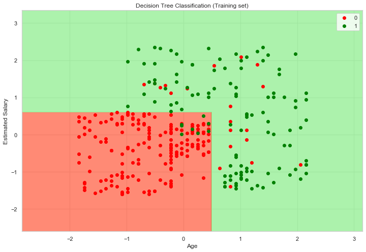

```python
# visualization
plt.figure(figsize=(12,8))

X_set, y_set = X_train, y_train.iloc[:,0].values
X1, X2 = np.meshgrid(np.arange(start = X_set[:, 0].min() - 1, stop = X_set[:, 0].max() + 1, step = 0.01),
                     np.arange(start = X_set[:, 1].min() - 1, stop = X_set[:, 1].max() + 1, step = 0.01))


from matplotlib.colors import ListedColormap
plt.contourf( X1, X2 , dtree.predict(np.array([X1.ravel(), X2.ravel()]).T).reshape(X1.shape),
             alpha = 0.75, cmap = ListedColormap(('#FF6347', '#90EE90')))

plt.xlim(X1.min(), X1.max())
plt.ylim(X2.min(), X2.max())

for i, j in enumerate(np.unique(y_set)):
    plt.scatter(X_set[y_set == j, 0], X_set[y_set == j, 1],
                c = ListedColormap(('red', 'green'))(i), label = j)
plt.title('Decision Tree Classification (Training set)')
plt.xlabel('Age')
plt.ylabel('Estimated Salary')
plt.legend()
plt.show()
```

**Exercise**

1. If you use max_depth=100, what is the accuracy in the training set?

### Visualising the Test set results

[output not shown]

[figure not shown]

```python
plt.figure(figsize=(12,8))

from matplotlib.colors import ListedColormap
X_set, y_set = X_test, y_test.iloc[:,0].values
X1, X2 = np.meshgrid(np.arange(start = X_set[:, 0].min() - 1, stop = X_set[:, 0].max() + 1, step = 0.01),
                     np.arange(start = X_set[:, 1].min() - 1, stop = X_set[:, 1].max() + 1, step = 0.01))
plt.contourf(X1, X2, dtree.predict(np.array([X1.ravel(), X2.ravel()]).T).reshape(X1.shape),
             alpha = 0.75, cmap = ListedColormap(('#FF6347', '#90EE90')))
plt.xlim(X1.min(), X1.max())
plt.ylim(X2.min(), X2.max())
for i, j in enumerate(np.unique(y_set)):
    plt.scatter(X_set[y_set == j, 0], X_set[y_set == j, 1],
                c = ListedColormap(('red', 'green'))(i), label = j)
plt.title('SVM Classification (Test set)')
plt.xlabel('Age')
plt.ylabel('Estimated Salary')
plt.legend()
plt.show()
```

```python
print(confusion_matrix(y_test, y_hat_vis))
```

```
[[47  5]
 [ 1 27]]
```

### Additional links:

1. Decision Trees with sklearn: https://scikit-learn.org/stable/modules/tree.html
2. Decision Trees visualization: https://mljar.com/blog/visualize-decision-tree/